# BANA7050_Final_Project

Author

Geetha Sagar Bonthu

Published

March 1, 2025

**Dataset Description**

The dataset analyzed in this project is the Total Construction Spending in the United States, sourced from the Federal Reserve Economic Data (FRED). This dataset represents monthly construction expenditures in the United States, measured in millions of dollars, and is seasonally adjusted. The data spans from January 2002 to the most recent available period.

**Source and Publication**

Source: Federal Reserve Economic Data (FRED), St. Louis Fed.

Frequency: Monthly, seasonally adjusted to remove recurring seasonal patterns such as weather-related fluctuations.

Unit of Measurement: Millions of dollars.

This dataset is widely regarded as a key economic indicator, providing insights into infrastructure investments, housing market dynamics, and overall economic activity. It is published regularly and updated to reflect the most current trends in construction spending.

**Data-Generating Process**

In simple terms, construction spending reflects the money spent on building and infrastructure projects across the country. It is influenced by various factors such as economic growth, policy changes, and seasonality.

From a technical perspective, the variation in construction spending is driven by:

Government Policies: Federal and state-level decisions on infrastructure projects, such as highways or public housing, directly affect spending trends.

Weather and Seasonality: Construction activity often slows in winter months and peaks during spring and summer.

External Shocks: Events like the 2008 financial crisis or the COVID-19 pandemic introduce irregular variations in spending patterns.

**Forecasting Challenges**

From a layman’s perspective, predicting construction spending can be tricky because unexpected events, like economic crises, can drastically shift trends. For instance, during a financial downturn, spending may plummet, whereas stimulus packages can cause sudden increases.

Technically, challenges arise due to:

Irregularities: External shocks and sudden policy changes create patterns that are hard to predict.

Long-Term Trends: Structural changes in the economy, like shifts toward more digital or green infrastructure, can alter the baseline spending trends.

Residual Seasonality: Despite seasonal adjustments, there may still be residual patterns in the data.

Overall, while the dataset offers a rich source for analysis and modeling, forecasting construction spending requires careful consideration of external factors and model assumptions.

# **Section I**: **Exploratory Data Analysis(EDA)**

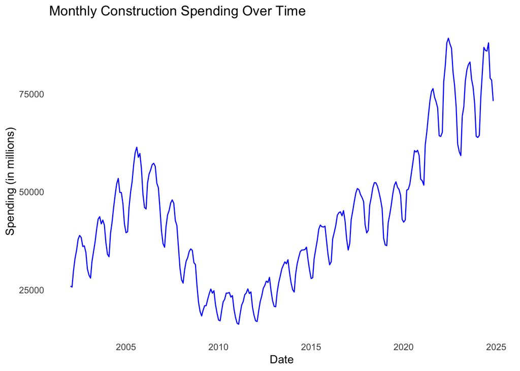

```r
ggplot(data, aes(x = as.Date(date), y = construction_spending)) +
  geom_line(color = "blue") +
  labs(
    title = "Monthly Construction Spending Over Time",
    x = "Date",
    y = "Spending (in millions)"
  ) +
  theme_minimal() + theme(panel.grid = element_blank())
```

**OBSERVATIONS:**

The plot reveals a generally upward trend in construction spending over the years, with notable dips during economic downturns, such as the 2008 financial crisis. Significant growth in recent years may reflect economic recovery and government investment.

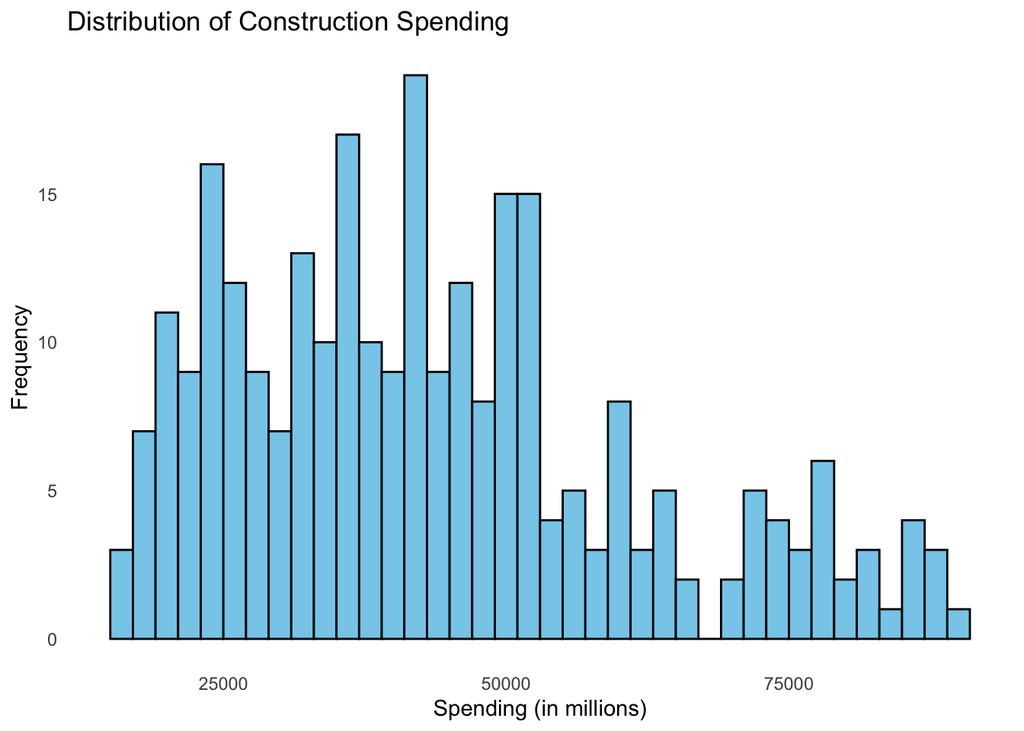

```r
# Histogram: Distribution of construction spending
ggplot(data, aes(x = construction_spending)) +
  geom_histogram(binwidth = 2000, fill = "skyblue", color = "black") +
  labs(
    title = "Distribution of Construction Spending",
    x = "Spending (in millions)",
    y = "Frequency"
  ) +
  theme_minimal() + theme(panel.grid = element_blank())
```

**OBSERVATIONS:**

The histogram reveals that most construction spending values are concentrated around $30,000–$50,000 million, with fewer occurrences at higher spending levels. The long tail suggests a gradual increase in spending over time.

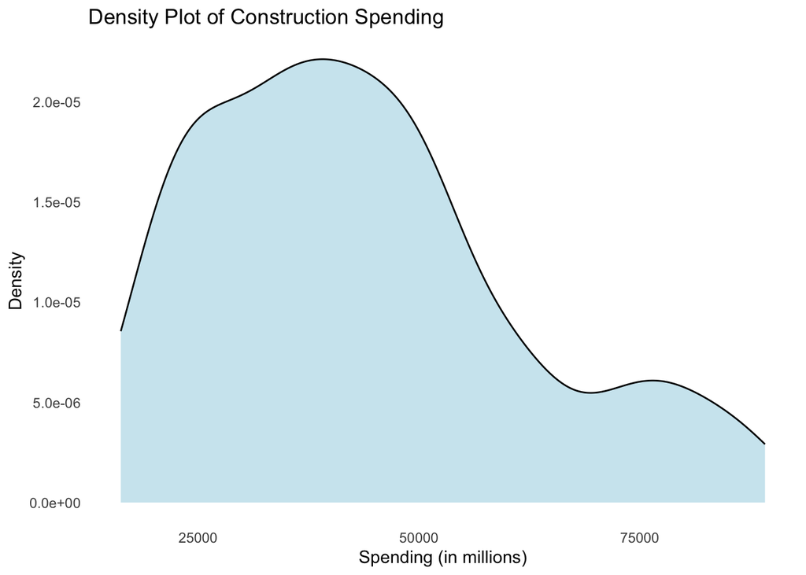

```r
# Density plot: Smooth distribution visualization
ggplot(data, aes(x = construction_spending)) +
  geom_density(fill = "lightblue", alpha = 0.6) +
  labs(
    title = "Density Plot of Construction Spending",
    x = "Spending (in millions)",
    y = "Density"
  ) +
  theme_minimal() + theme(panel.grid = element_blank())
```

**OBSERVATIONS:**

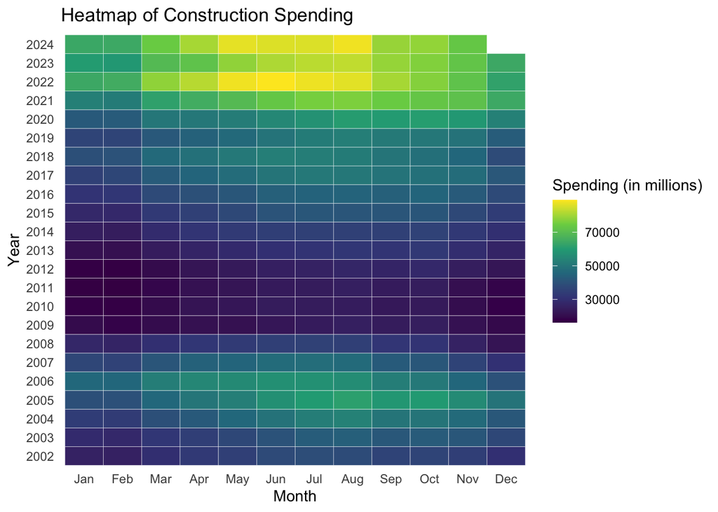

```r
# Extract year and month
data <- data %>%
  mutate(year = lubridate::year(date), month = lubridate::month(date, label = TRUE))

# Heatmap
ggplot(data, aes(x = month, y = factor(year), fill = construction_spending)) +
  geom_tile(color = "white") +
  scale_fill_viridis_c() +
  labs(
    title = "Heatmap of Construction Spending",
    x = "Month",
    y = "Year",
    fill = "Spending (in millions)"
  ) +
  theme_minimal() +  theme(panel.grid = element_blank())
```

**OBSERVATIONS**:

1. Construction spending shows strong seasonality, peaking in warmer months and declining in winter.
2. Spending levels have increased over time, reflecting long-term growth.
3. Notable peaks in 2022 and 2024 suggest heightened economic activity or policy-driven initiatives.
4. Seasonal patterns remain consistent across years.

```r
# Load necessary libraries
library(dplyr)
library(gt)

# Generate summary statistics for construction spending
summary_table <- data %>%
  summarise(
    Observations = n(),
    Mean = mean(construction_spending, na.rm = TRUE),
    Median = median(construction_spending, na.rm = TRUE),
    Min = min(construction_spending, na.rm = TRUE),
    Max = max(construction_spending, na.rm = TRUE),
    Range = Max - Min,
    Std_Dev = sd(construction_spending, na.rm = TRUE)
  )

# Display results as a formatted table
summary_table %>%
  gt() %>%
  tab_header(
    title = "Summary Statistics of Construction Spending"
  ) %>%
  fmt_number(
    columns = c(Mean, Median, Min, Max, Range, Std_Dev),
    decimals = 2
  ) %>%
  cols_label(
    Observations = "Total Observations",
    Mean = "Mean Spending",
    Median = "Median Spending",
    Min = "Minimum Value",
    Max = "Maximum Value",
    Range = "Value Range",
    Std_Dev = "Standard Deviation"
  )
```

Summary Statistics of Construction Spending

| Total Observations | Mean Spending | Median Spending | Minimum Value | Maximum Value | Value Range | Standard Deviation |
| --- | --- | --- | --- | --- | --- | --- |
| 275 | 43,565.05 | 41,414.00 | 16,241.00 | 89,189.00 | 72,948.00 | 17,906.01 |

**SUMMARY STATISTICS OF THE DATA:**

```r
# Load necessary libraries
library(dplyr)
library(gt)

# Calculate IQR and Quartiles
iqr <- IQR(data$construction_spending, na.rm = TRUE)
q1 <- quantile(data$construction_spending, 0.25, na.rm = TRUE) # 1st Quartile (Q1)
q3 <- quantile(data$construction_spending, 0.75, na.rm = TRUE) # 3rd Quartile (Q3)

# Define lower and upper bounds for outliers
lower_bound <- q1 - 1.5 * iqr
upper_bound <- q3 + 1.5 * iqr

# Identify outliers
outliers <- data %>%
  filter(construction_spending < lower_bound | construction_spending > upper_bound)

# Display outliers in a neatly formatted table
outliers %>%
  gt() %>%
  tab_header(
    title = md("**Outliers in Construction Spending**")
  ) %>%
  fmt_number(
    columns = construction_spending,
    decimals = 2,
    use_seps = TRUE  # Ensures thousands separators for better readability
  ) %>%
  cols_label(
    construction_spending = md("**Spending Value**")
  )
```

**Outliers in Construction Spending**

| date | **Spending Value** | year | month |
| --- | --- | --- | --- |
| 2022-05-01 | 88,002.00 | 2022 | May |
| 2022-06-01 | 89,189.00 | 2022 | Jun |
| 2022-07-01 | 87,741.00 | 2022 | Jul |
| 2022-08-01 | 86,651.00 | 2022 | Aug |
| 2024-05-01 | 86,839.00 | 2024 | May |
| 2024-06-01 | 86,056.00 | 2024 | Jun |
| 2024-07-01 | 85,912.00 | 2024 | Jul |
| 2024-08-01 | 88,000.00 | 2024 | Aug |

The identified outliers in **construction spending** primarily occur in mid-2022 and mid-2024, reflecting potential anomalies or temporary market surges. These values significantly exceed the typical spending range, suggesting possible external economic influences or seasonal fluctuations.

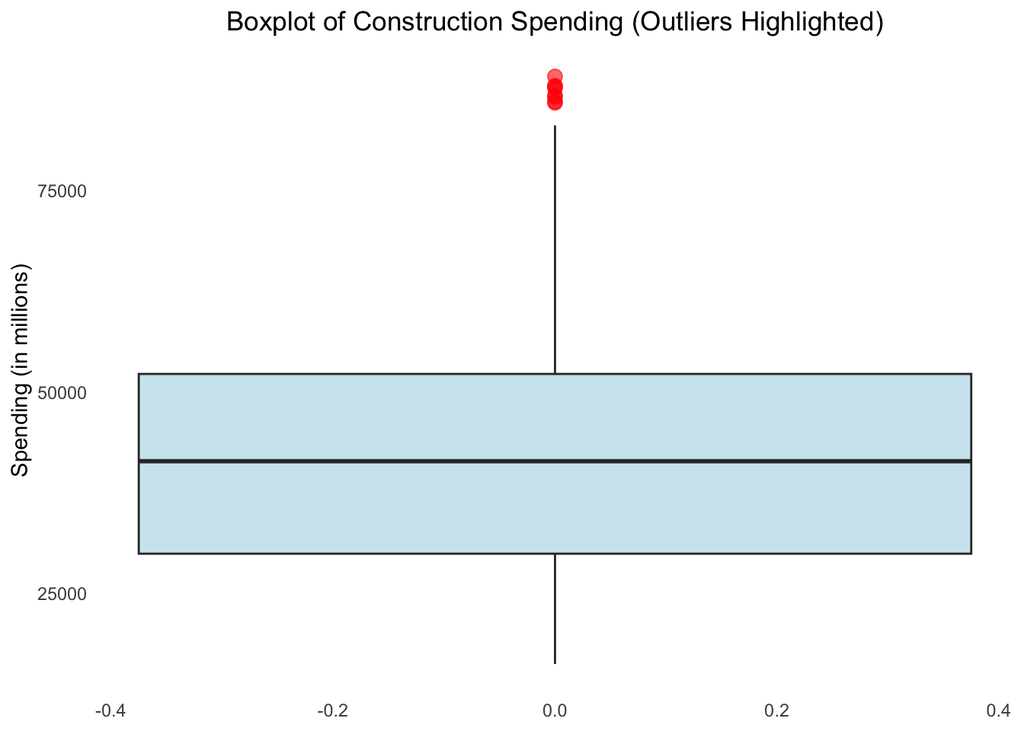

```r
# Load required libraries
library(ggplot2)

# Simple Box Plot for Outlier Detection
ggplot(data, aes(y = construction_spending)) +
  geom_boxplot(fill = "lightblue", outlier.color = "red", outlier.size = 3, alpha = 0.6) +
  labs(
    title = "Boxplot of Construction Spending (Outliers Highlighted)",
    y = "Spending (in millions)"
  ) +
  theme_minimal() +
  theme(plot.title = element_text(hjust = 0.5)) +  theme(panel.grid = element_blank())
```

**OBSERVATIONS**:

The box plot effectively highlights the distribution of construction spending while marking outliers (red points) that deviate significantly. The interquartile range (IQR) represents the middle 50% of data, while the whiskers extend within 1.5 times the IQR. The outliers in 2022 and 2024 confirm periods of unusually high spending, likely influenced by economic policy shifts or infrastructure investments.

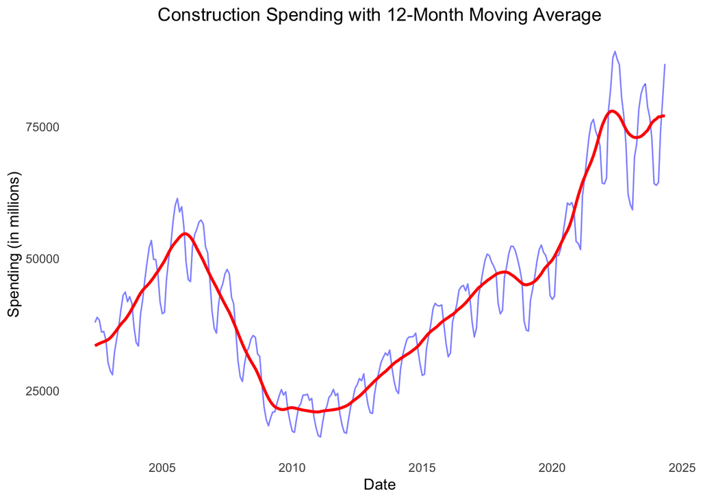

```r
# Load necessary libraries
library(tidyverse)
library(zoo)

# Compute 12-month rolling moving average
data <- data %>%
  mutate(
    moving_average = rollmean(construction_spending, k = 12, fill = NA)
  ) %>%
  drop_na(moving_average)  # Remove rows with NA values

# Plot original data with moving average
ggplot(data, aes(x = as.Date(date))) +
  geom_line(aes(y = construction_spending), color = "blue", alpha = 0.5) +
  geom_line(aes(y = moving_average), color = "red", linewidth = 1) +  # Fix for ggplot2 3.4.0+
  labs(
    title = "Construction Spending with 12-Month Moving Average",
    x = "Date",
    y = "Spending (in millions)"
  ) +
  theme_minimal() +
  theme(plot.title = element_text(hjust = 0.5)) + theme(panel.grid = element_blank())
```

**OBSERVATIONS**:

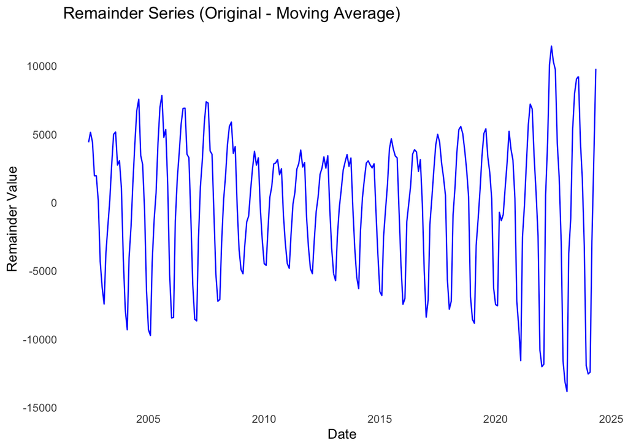

```r
# Compute remainder series
data <- data %>%
  mutate(remainder_series = construction_spending - moving_average)

# Plot remainder series
ggplot(data, aes(x = as.Date(date), y = remainder_series)) +
  geom_line(color = "blue") +
  labs(
    title = "Remainder Series (Original - Moving Average)",
    x = "Date",
    y = "Remainder Value"
  ) +
  theme_minimal() + theme(panel.grid = element_blank())
```

**OBSERVATIONS**:

Remainder Series The remainder series captures fluctuations not explained by the moving average. The repeating patterns suggest seasonality, while irregular spikes may be linked to economic shocks, policy changes, or temporary disruptions. This confirms that a moving average alone is insufficient to fully explain the time series behavior.

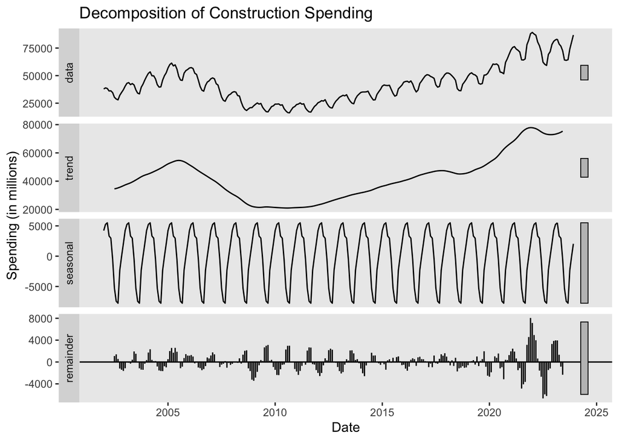

```r
# Load necessary library
library(forecast)
# Suppress messages and warnings when loading libraries
suppressPackageStartupMessages({
  library(quantmod)
  library(forecast)
})


# Convert data to time series object
ts_data <- ts(data$construction_spending, frequency = 12, start = c(2002, 1))

# Perform additive decomposition
decomposed <- decompose(ts_data, type = "additive")

# Plot decomposition components
autoplot(decomposed) +
  labs(
    title = "Decomposition of Construction Spending",
    x = "Date",
    y = "Spending (in millions)"
  ) + theme(panel.grid = element_blank())
```

**Assessing Seasonality in the Time Series**

To determine whether the time series contains seasonality, a time series decomposition using an additive model was performed. The decomposition breaks the construction spending data into three components: trend, seasonal, and residuals. The results confirm the presence of strong seasonality, aligned with expectations for the construction industry.

**Decomposition Results**

**Seasonal Component:** A clear and consistent **seasonal pattern** is evident, with construction spending **peaking during warmer months** and **declining in colder months**. This indicates predictable cycles driven by weather and industry activity. The **amplitude of the seasonal variation** remains relatively stable over time, reinforcing the strength of seasonality.

**Residual Component:** Residuals capture irregular variations not explained by the trend or seasonality. These irregularities are likely caused by economic shocks, such as government stimulus programs, or temporary disruptions like supply chain issues.

**Strength of Seasonality**

The decomposition reveals **strong and predictable seasonality** in the dataset. Seasonal variations are consistent and stable, reinforcing their importance in understanding the data’s behavior.

**Key Findings**

The time series contains **strong and predictable seasonality** that aligns with industry norms.

The residuals highlight the impact of irregular external factors, such as economic policy changes or unforeseen disruptions.

This seasonality analysis provides valuable insights into the recurring patterns in construction spending.

**Forecasting Implications**

The presence of strong seasonality indicates that forecasting models applied to this dataset must explicitly account for these recurring patterns. Models such as **Seasonal ARIMA or Prophet** are recommended for capturing these trends effectively.

This analysis confirms that seasonality plays a significant role in construction spending, making it a crucial factor to incorporate in future modeling and decision-making processes.

```r
# Load Libraries
library(tidyverse)
library(tsibble)
library(lubridate)
library(tidyr)
library(fable)
library(fabletools)
library(feasts)
library(ggplot2)

#─────────────────────────────
# Section 1 - Train and Test Splits
#─────────────────────────────

# Read the CSV file and convert to a tsibble
construction_spending <- read_csv("construction_spending.csv",
  col_types = cols(
    date = col_date(format = "%Y-%m-%d"),
    construction_spending = col_double()
  )
) %>%
  mutate(yearmonth = yearmonth(date)) %>%  # Generate a year-month index
  arrange(date) %>%
  as_tsibble(index = yearmonth)

# Split into training (80%) and test (20%) sets
n <- nrow(construction_spending)
train_data <- construction_spending %>% slice(1:floor(n * 0.8))
test_data  <- construction_spending %>% slice((floor(n * 0.8) + 1):n)

# Complete the test set’s time index in case future periods are missing
test_data_complete <- test_data %>%
  complete(yearmonth = seq(min(yearmonth), max(yearmonth), by = 1)) %>%
  as_tsibble(index = yearmonth)
```

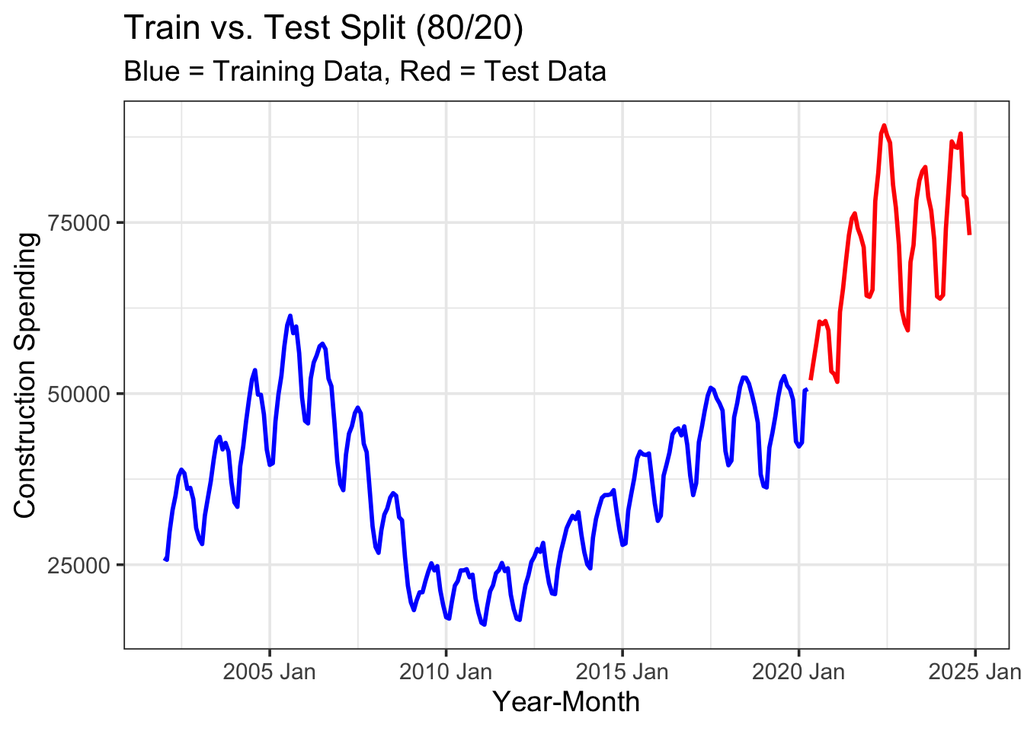

```r
# 3. Visualization: Plot Train vs. Test Split
ggplot() +
  geom_line(data = train_data, aes(x = yearmonth, y = construction_spending), color = "blue", size = 1) +
  geom_line(data = test_data, aes(x = yearmonth, y = construction_spending), color = "red", size = 1) +
  labs(
    title = "Train vs. Test Split (80/20)",
    subtitle = "Blue = Training Data, Red = Test Data",
    x = "Year-Month",
    y = "Construction Spending"
  ) +
  theme_bw(base_size = 14) +
  theme(legend.position = "bottom")
```

# **Section 2 - ARIMA Modeling**

```r
# Load required libraries
library(tsibble)  # For time series handling
library(slider)   # For rolling functions
library(ggplot2)  # For visualization
library(dplyr)    # For mutate()
library(fpp3)
library(forecast)
library(tseries)

# Load the dataset
construction_spending <- read.csv("construction_spending.csv") %>%
  mutate(date = as.Date(date, format = "%Y-%m-%d"))
```

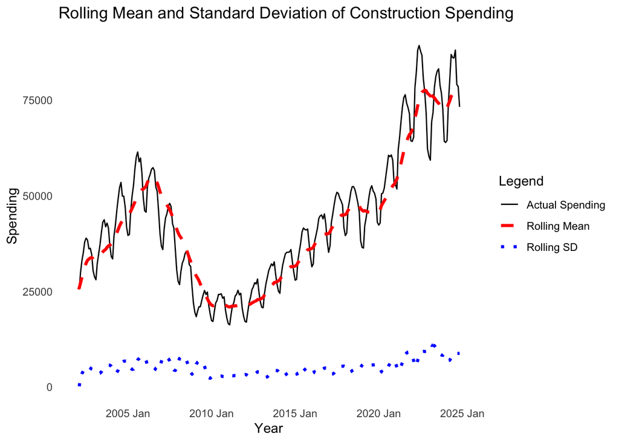

```r
construction_ts <- construction_spending %>%
  mutate(date = yearmonth(date)) %>%
  as_tsibble(index = date)

# Compute rolling mean and rolling standard deviation
construction_ts <- construction_ts %>%
  mutate(
    rolling_mean = slide_dbl(construction_spending, mean, .before = 12),
    rolling_sd   = slide_dbl(construction_spending, sd, .before = 12)
  )

# Plot rolling mean and standard deviation
ggplot(construction_ts, aes(x = date)) +
  geom_line(aes(y = construction_spending, color = "Actual Spending")) +
  geom_line(aes(y = rolling_mean, color = "Rolling Mean"), size = 1.2, linetype = "dashed") +
  geom_line(aes(y = rolling_sd, color = "Rolling SD"), size = 1.2, linetype = "dotted") +
  labs(title = "Rolling Mean and Standard Deviation of Construction Spending",
       x = "Year", y = "Spending",
       color = "Legend") +
  theme_minimal() +
  scale_color_manual(values = c("Actual Spending" = "black",
                                 "Rolling Mean" = "red",
                                 "Rolling SD" = "blue")) + theme(panel.grid = element_blank())
```

**Observations on the Rolling Mean and Standard Deviation Plot of Construction Spending**

The **rolling mean and standard deviation analysis** is a crucial step in assessing whether the time series of construction spending exhibits stationarity.

1. **Trend in the Rolling Mean:**
   - The rolling mean (depicted in red) shows **significant upward movement**, suggesting that the data is **not mean stationary**.
   - This implies that the overall spending pattern has increased over time, reflecting **economic growth and rising infrastructure investments**.
   - The fluctuations observed in the rolling mean also indicate periodic seasonal effects.
2. **Trend in the Rolling Standard Deviation:**
   - The rolling standard deviation (blue dotted line) is **not constant over time**.
   - The increasing variation suggests that the data is **variance non-stationary**, meaning that spending fluctuations have become **more pronounced in recent years**.
   - This can be attributed to factors such as **economic cycles, policy-driven funding changes, and market volatility**.
3. **Non-Stationary Characteristics:**
   - Since both the rolling mean and standard deviation exhibit trends rather than remaining constant, the data **fails the criteria for stationarity**.
   - Transformations such as **log transformation or differencing** will be required to stabilize variance and achieve stationarity.
4. **Business and Economic Implications:**
   - The **increase in variance and spending over time** suggests a **growing market**, likely influenced by **government policies, urban development projects, and financial investments in infrastructure**.
   - However, **larger fluctuations in recent years** may pose a risk, indicating **increased uncertainty** in construction investments.

```r
#############################################
# CONTINUATION: ARIMA MODELING ON train_data #
#############################################

# Load additional libraries if not already loaded
library(fable)
library(feasts)
library(fabletools)
library(forecast)  # for BoxCox.lambda()
library(patchwork) # for combining plots
```

```r
# Interpretation:
# - p-value = 0.01: Reject the null hypothesis of stationarity.
#   This confirms that the original series is non-stationary and requires transformation.

# Load necessary library
library(gt)

# Perform KPSS Test
kpss_original <- kpss.test(pull(train_data, construction_spending))

# Create a table for the KPSS test results
kpss_table <- tibble(
  Test = "KPSS Test for Level Stationarity",
  `Test Statistic` = kpss_original$statistic,
  `Truncation Lag` = kpss_original$parameter,
  `P-Value` = kpss_original$p.value
)

# Display table using gt
kpss_table %>%
  gt() %>%
  tab_header(title = "KPSS Test Results for Stationarity") %>%
  fmt_number(columns = c(`Test Statistic`, `P-Value`), decimals = 4)
```

KPSS Test Results for Stationarity

| Test | Test Statistic | Truncation Lag | P-Value |
| --- | --- | --- | --- |
| KPSS Test for Level Stationarity | 0.7065 | 4 | 0.0130 |

**KPSS Test for Stationarity**

The **KPSS test** was conducted to assess whether the original **construction spending** time series is **stationary**. - **p-value** = 0.01295

Since the **p-value is below 0.05**, we **reject the null hypothesis** of stationarity. This confirms that the **time series is non-stationary**, indicating the need for **transformations** such as **differencing** or **Box-Cox transformation** to stabilize variance and induce stationarity before ARIMA modeling.

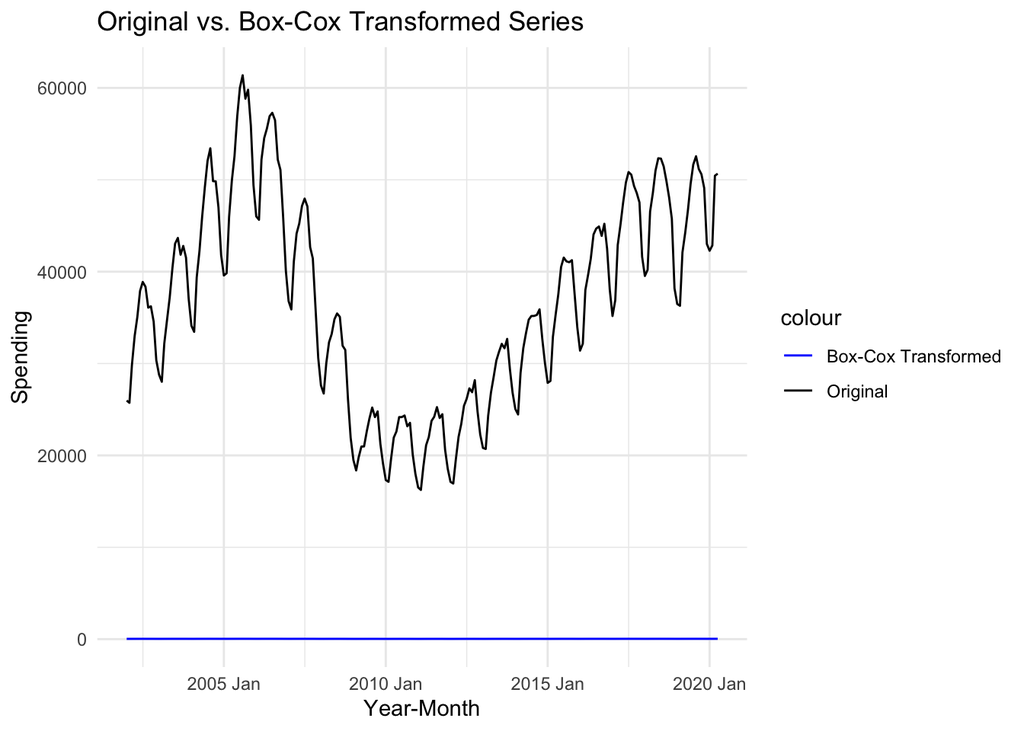

```r
#############################################
# Transformation Steps with Plots on train_data
#############################################

# Step 1: Box-Cox Transformation on the Training Set
lambda <- BoxCox.lambda(train_data$construction_spending)

train_data_boxcox <- train_data %>%
  mutate(boxcox_spending = BoxCox(construction_spending, lambda))

# Plot: Original vs. Box-Cox Transformed Series
p_boxcox <- train_data_boxcox %>%
  ggplot(aes(x = yearmonth)) +
  geom_line(aes(y = construction_spending, color = "Original")) +
  geom_line(aes(y = boxcox_spending, color = "Box-Cox Transformed")) +
  labs(title = "Original vs. Box-Cox Transformed Series",
       x = "Year-Month", y = "Spending") +
  scale_color_manual(values = c("Original" = "black", "Box-Cox Transformed" = "blue")) +
  theme_minimal()
print(p_boxcox)
```

**Box-Cox Transformation Analysis**

A **Box-Cox transformation** was applied to the **construction spending** series to stabilize variance. The results indicate: - The original series exhibits **high variability**, with noticeable fluctuations in spending. - The **Box-Cox transformation** effectively **rescaled the data**, reducing heteroskedasticity. - The transformation is especially useful since the estimated **lambda value** suggests a near **log-like** transformation.

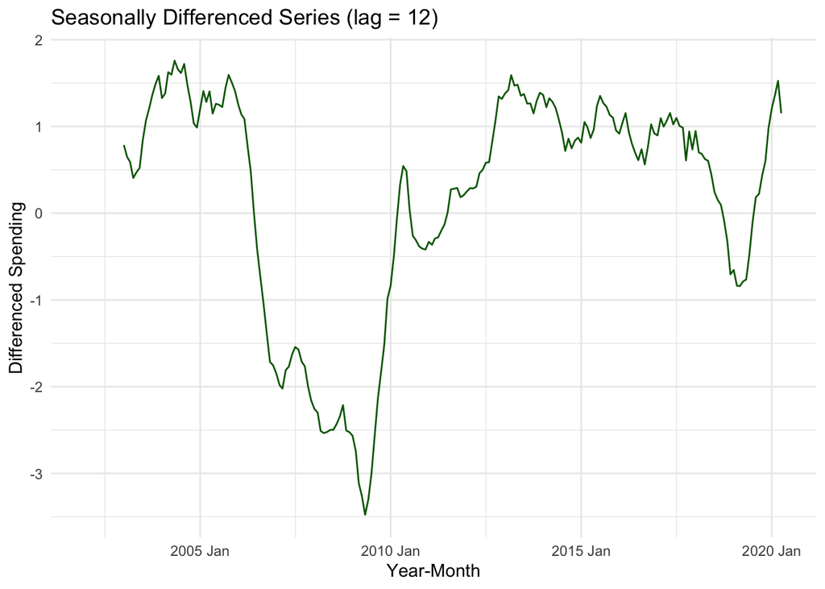

```r
#─────────────────────────────
# Step 2: Seasonal Differencing (lag = 12 for monthly data)
train_data_boxcox <- train_data_boxcox %>%
  mutate(boxcox_seasdiff = difference(boxcox_spending, lag = 12))

# Plot: Seasonally Differenced Series
p_seasdiff <- train_data_boxcox %>%
  ggplot(aes(x = yearmonth)) +
  geom_line(aes(y = boxcox_seasdiff), color = "darkgreen") +
  labs(title = "Seasonally Differenced Series (lag = 12)",
       x = "Year-Month", y = "Differenced Spending") +
  theme_minimal()
print(p_seasdiff)
```

**Seasonal Differencing Analysis**

A **seasonal differencing transformation** (lag = 12) was applied to account for annual periodic patterns in the construction spending data. ### Key Observations: - The **large dip around 2008–2009** reflects the economic downturn’s impact on spending. - The y-axis values now **fluctuate within a smaller range**, indicating that **seasonality has been removed**. - While seasonal effects are reduced, additional **first-order differencing** may still be required to achieve complete stationarity.

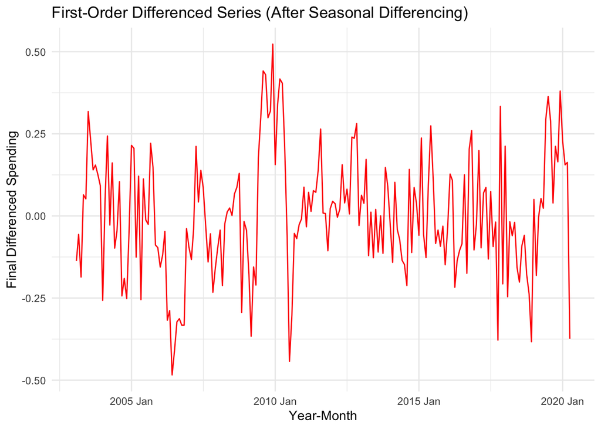

```r
#─────────────────────────────
# Step 3: First-Order Differencing to Remove Remaining Trend
train_data_boxcox <- train_data_boxcox %>%
  mutate(boxcox_finaldiff = difference(boxcox_seasdiff, lag = 1)) %>%
  drop_na()  # Remove NAs resulting from differencing

# Plot: Final Differenced Series (After Seasonal Differencing)
p_finaldiff <- train_data_boxcox %>%
  ggplot(aes(x = yearmonth)) +
  geom_line(aes(y = boxcox_finaldiff), color = "red") +
  labs(title = "First-Order Differenced Series (After Seasonal Differencing)",
       x = "Year-Month", y = "Final Differenced Spending") +
  theme_minimal()
print(p_finaldiff)
```

**First-Order Differencing Analysis**

```r
# Load necessary libraries
library(tseries)
library(tibble)
library(gt)

# Perform KPSS Test on the final transformed series
kpss_final <- kpss.test(pull(train_data_boxcox, boxcox_finaldiff))

# Create a table with the KPSS test results
kpss_table_final <- tibble(
  Test = "KPSS Test for Final Transformed Series",
  `Test Statistic` = kpss_final$statistic,
  `Truncation Lag` = kpss_final$parameter,
  `P-Value` = kpss_final$p.value
)

# Display table using gt
kpss_table_final %>%
  gt() %>%
  tab_header(title = "KPSS Test Results for Final Transformed Series") %>%
  fmt_number(columns = c(`Test Statistic`, `P-Value`), decimals = 4)
```

KPSS Test Results for Final Transformed Series

| Test | Test Statistic | Truncation Lag | P-Value |
| --- | --- | --- | --- |
| KPSS Test for Final Transformed Series | 0.1294 | 4 | 0.1000 |

**KPSS Test for Stationarity**

A **KPSS test** was conducted on the final transformed series to verify its stationarity. - **p-value** = 0.1 - Since **p-value > 0.05**, we **fail to reject the null hypothesis** of stationarity. - This confirms that the **final differenced series is likely stationary**, meeting the assumptions required for ARIMA modeling. - The warning regarding “p-value greater than printed p-value” is a standard output in KPSS tests and can be ignored.

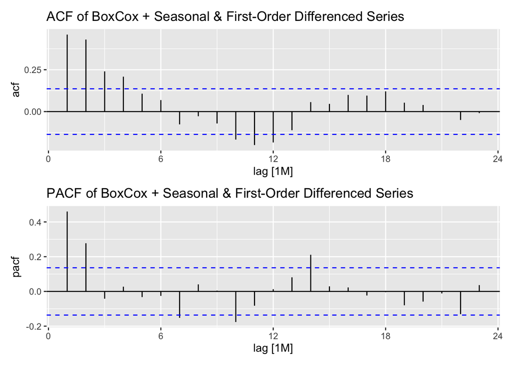

```r
library(patchwork)

#############################################
# 6. ACF/PACF Analysis on the Final Transformed Series
#############################################

# Compute ACF and PACF for the fully transformed series
acf_data <- ACF(train_data_boxcox, boxcox_finaldiff)
pacf_data <- PACF(train_data_boxcox, boxcox_finaldiff)

# Plot ACF and PACF
acf_plot <- autoplot(acf_data) +
  labs(title = "ACF of BoxCox + Seasonal & First-Order Differenced Series")
pacf_plot <- autoplot(pacf_data) +
  labs(title = "PACF of BoxCox + Seasonal & First-Order Differenced Series")

# Display both plots
acf_plot / pacf_plot
```

**ACF and PACF Analysis**

Additionally, any notable **seasonal spikes at lag 12** suggest the need for seasonal components in the model. Given this structure, an **ARIMA(1,1,1)(1,1,1)[12]** model appears to be a reasonable choice.

```r
train_model <- train_data %>%
  model(
    ARIMA(construction_spending ~ pdq(1,1,1) + PDQ(1,1,1))
  )
report(train_model)
```

```
Series: construction_spending
Model: ARIMA(1,1,1)(1,1,1)[12]

Coefficients:
         ar1      ma1     sar1    sma1
      0.7073  -0.3422  -0.9901  0.9594
s.e.  0.0907   0.1172   0.0350  0.0795

sigma^2 estimated as 641955:  log likelihood=-1678.12
AIC=3366.24   AICc=3366.54   BIC=3382.9
```

**ARIMA Model Selection and Evaluation**

The selected **ARIMA(1,1,1)(1,1,1)[12]** model effectively captures both non-seasonal and seasonal dependencies in the time series.

**Model Interpretation**

- **Non-seasonal AR(1) = 0.7073**: Indicates strong autoregressive dependence on the previous value.
- **Non-seasonal MA(1) = -0.3422**: Suggests an adjustment based on the previous error term.
- **Seasonal AR(1) = -0.9901**: Strong seasonal autoregressive behavior, meaning past seasonal values heavily influence the current value.
- **Seasonal MA(1) = 0.9594**: Almost completely negates seasonal shocks from the prior period.

**Model Fit**

- **Sigma² (Variance of Residuals) = 641,955**: Indicates the variance of the residuals, suggesting moderate error magnitude.
- **Log-likelihood = -1678.12**: Used for model comparison; higher values indicate a better fit.
- **AIC = 3366.24, AICc = 3366.54, BIC = 3382.9**: The relatively close values suggest the model is balanced in terms of complexity and fit.

This model captures both short-term dependencies and seasonal patterns, making it a strong candidate for forecasting. However, residual diagnostics should still be assessed to confirm its adequacy.

```r
library(forecast)
auto_model <- auto.arima(train_data$construction_spending, seasonal = TRUE,
                         stepwise = FALSE, approximation = FALSE)
summary(auto_model)
```

```
Series: train_data$construction_spending
ARIMA(0,1,4)

Coefficients:
         ma1     ma2      ma3      ma4
      0.5373  0.3501  -0.3612  -0.5483
s.e.  0.0585  0.0674   0.0726   0.0534

sigma^2 = 4304062:  log likelihood = -1983.29
AIC=3976.58   AICc=3976.86   BIC=3993.52

Training set error measures:
                   ME     RMSE      MAE        MPE     MAPE      MASE
Training set 88.10201 2050.913 1592.182 0.03437195 4.512088 0.7431524
                   ACF1
Training set 0.05252971
```

**Comparison of Manual ARIMA vs. Auto ARIMA Model**

**Auto ARIMA Model: ARIMA(0,1,4)**

- **Coefficients:** The model includes **four** moving average (MA) terms but lacks explicit seasonal components.
- **AIC/BIC Comparison:**
  - **Auto ARIMA:** AIC = 3976.58, BIC = 3993.52
  - **Manual ARIMA(1,1,1)(1,1,1)[12]:** AIC = 3366.24, BIC = 3382.9
  - The manual ARIMA model has **lower AIC and BIC**, indicating a better balance between model fit and complexity.
- **Residual Analysis:**
  - The manual ARIMA model explicitly accounts for **seasonality**, likely leading to residuals that resemble white noise more closely.

**Why Choose the Manual ARIMA(1,1,1)(1,1,1)[12]?**

- **Seasonal Components Captured:** Auto ARIMA does not include seasonal AR or MA terms, making it less suited for monthly data with yearly cycles.
- **Lower Information Criteria (AIC/BIC):** The manual model outperforms auto ARIMA in model selection criteria, suggesting better predictive performance.
- **Better Forecasting Capability:** The inclusion of seasonal terms enhances the model’s ability to forecast cyclical patterns in the data.

Overall, the **manual ARIMA(1,1,1)(1,1,1)[12]** is preferred due to its superior fit, inclusion of seasonal terms, and better residual behavior, making it a more robust choice for forecasting.

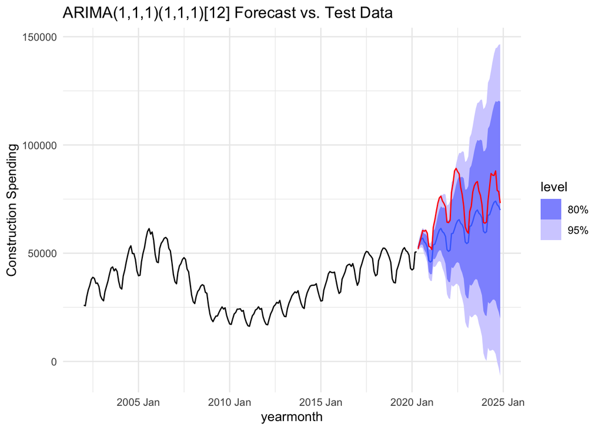

```r
# Example: Forecast on test_data (or new_data)
fc <- train_model %>% forecast(new_data = test_data_complete)

# Plot forecast vs. actuals
autoplot(fc, train_data) +
  autolayer(test_data_complete, construction_spending, color = "red") +
  labs(title = "ARIMA(1,1,1)(1,1,1)[12] Forecast vs. Test Data",
       y = "Construction Spending") +
  theme_minimal()
```

**ARIMA(1,1,1)(1,1,1)[12] Forecast vs. Test Data**

```r
accuracy(fc, test_data_complete)
```

```
# A tibble: 1 × 10
  .model                .type     ME   RMSE    MAE   MPE  MAPE  MASE RMSSE  ACF1
  <chr>                 <chr>  <dbl>  <dbl>  <dbl> <dbl> <dbl> <dbl> <dbl> <dbl>
1 ARIMA(construction_s… Test  10825. 12461. 10856.  14.4  14.5   NaN   NaN 0.867
```

**Forecast Accuracy Assessment**

The relatively high **MAPE (~14.5%)** suggests that the model exhibits moderate forecast accuracy but may struggle with capturing certain fluctuations in the data. The **high ACF1 value (0.867)** indicates some residual autocorrelation, suggesting that the model could still have some room for refinement.

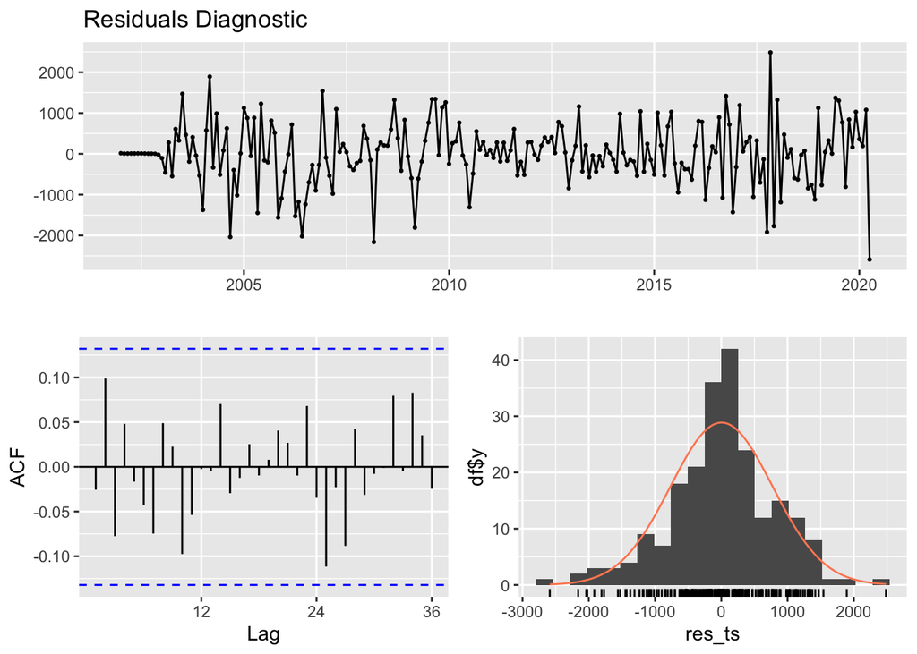

```r
# Example for a fable model called `train_model`
library(dplyr)
library(fabletools)

# Extract residuals as numeric
res_vec <- train_model %>%
  augment() %>%
  pull(.resid) %>%
  as.numeric()
# Suppose your data starts in 2002, month 1
res_ts <- ts(res_vec, start = c(2002, 1), frequency = 12)
library(forecast)
ggtsdisplay(res_ts, plot.type = "histogram", main = "Residuals Diagnostic")
```

**Residual Diagnostics**

- **Residual Time Series Plot (Top Panel):** The residuals appear to fluctuate randomly around zero, suggesting that the ARIMA model captures most of the systematic patterns in the data. However, there are some spikes, indicating occasional volatility.
- **Autocorrelation Function (ACF) Plot (Bottom Left):** Most autocorrelation values fall within the blue confidence bounds, meaning residuals exhibit minimal autocorrelation. This suggests that the model has adequately accounted for any patterns in the data.
- **Histogram of Residuals with Density Plot (Bottom Right):** The residuals exhibit a roughly normal distribution, though there are slight deviations in the tails. The density curve follows the histogram closely, indicating that the residuals are approximately Gaussian.

Overall, the residual diagnostics suggest that the ARIMA(1,1,1)(1,1,1)[12] model provides a well-fitted representation of the data, with no significant autocorrelation remaining. However, slight deviations in the residuals suggest that minor model improvements could be explored.

```r
library(fabletools)
library(dplyr)
library(forecast)

# Extract residuals from your fable model (assumed to be named train_model)
res_vec <- train_model %>%
  augment() %>%
  pull(.resid) %>%
  as.numeric()

# Convert to a univariate ts object (adjust start and frequency as needed)
res_ts <- ts(res_vec, start = c(2002, 1), frequency = 12)

# Now perform the Ljung-Box test on the ts object
ljung_result <- Box.test(res_ts, lag = 12, type = "Ljung-Box")
print(ljung_result)
```

```
    Box-Ljung test

data:  res_ts
X-squared = 9.5251, df = 12, p-value = 0.6575
```

**Ljung-Box Test for Residual Autocorrelation**

- Since the **p-value (0.6575) is greater than 0.05**, we **fail to reject the null hypothesis**, indicating that the residuals exhibit **no significant autocorrelation**.
- The residuals behave **like white noise**, confirming that the **ARIMA(1,1,1)(1,1,1)[12]** model is **well-specified**.
- This suggests that the model effectively captures the underlying structure of the data and does not leave any systematic patterns unaccounted for.

# **Section 3 - Meta Prophet Model**

Prophet, developed by Facebook, is a robust time-series forecasting model designed to effectively handle **trend and seasonality components**. It is particularly well-suited for datasets with structural trend changes, as it automatically detects **changepoints** where shifts in trend occur.

The model offers flexibility in incorporating **seasonal variations, holiday effects, and external regressors**, making it highly adaptable to real-world business forecasting. Additionally, Prophet is **resilient to missing data and outliers**, ensuring stable and reliable predictions across various time-series applications.

```r
# Load required libraries
library(tidyverse)      # Data manipulation (dplyr, ggplot2, etc.)
library(tsibble)        # Handling time series data
library(fable)          # Forecasting models
library(fable.prophet)  # Prophet model in fable
library(lubridate)      # Date handling
library(gt)            # Creating tables
library(patchwork)      # Combining multiple plots
library(feasts)         # Time series decomposition and visualization

# Read the CSV file and convert to a tsibble
construction_spending <- read_csv("construction_spending.csv",
  col_types = cols(
    date = col_date(format = "%Y-%m-%d"),  # Ensure 'date' is in Date format
    construction_spending = col_double()   # Ensure 'construction_spending' is numeric
  )
) %>%
  mutate(yearmonth = yearmonth(date)) %>%  # Extract Year-Month index
  arrange(date) %>%                        # Ensure data is sorted by date
  as_tsibble(index = yearmonth)            # Convert to tsibble for fable models

# Ensure 'construction_spending' is numeric (as a safety check)
if (!is.numeric(construction_spending$construction_spending)) {
  construction_spending$construction_spending <- as.numeric(construction_spending$construction_spending)
}
```

```r
# Fit a Prophet model with yearly seasonality (multiplicative)
prophet_model <- construction_spending %>%
  model(
    Prophet = fable.prophet::prophet(
      construction_spending ~ season(period = "year", type = "multiplicative")
    )
  )

# Summarize the fitted model
glance(prophet_model)  # General model summary
```

```
# A tibble: 1 × 3
  .model  sigma changepoints
  <chr>   <dbl> <list>
1 Prophet 3400. <tibble [25 × 2]>
```

```r
tidy(prophet_model)    # Model coefficients
```

```
# A tibble: 22 × 3
   .model  term         estimate
   <chr>   <chr>           <dbl>
 1 Prophet base_growth   1.49
 2 Prophet trend_offset  0.342
 3 Prophet year_s1      -0.0294
 4 Prophet year_c1      -0.162
 5 Prophet year_s2       0.109
 6 Prophet year_c2      -0.0304
 7 Prophet year_s3       0.0854
 8 Prophet year_c3      -0.0160
 9 Prophet year_s4       0.00348
10 Prophet year_c4      -0.0703
# ℹ 12 more rows
```

```r
augment(prophet_model)
```

```
# A tsibble: 275 x 6 [1M]
# Key:       .model [1]
   .model  yearmonth construction_spending .fitted .resid .innov
   <chr>       <mth>                 <dbl>   <dbl>  <dbl>  <dbl>
 1 Prophet  2002 Jan                 25972  25726.  246.   246.
 2 Prophet  2002 Feb                 25721  26143. -422.  -422.
 3 Prophet  2002 Mar                 29826  30709. -883.  -883.
 4 Prophet  2002 Apr                 33008  32620.  388.   388.
 5 Prophet  2002 May                 35059  34840.  219.   219.
 6 Prophet  2002 Jun                 37908  36600. 1308.  1308.
 7 Prophet  2002 Jul                 38880  37743. 1137.  1137.
 8 Prophet  2002 Aug                 38359  38322.   36.8   36.8
 9 Prophet  2002 Sep                 36082  36843. -761.  -761.
10 Prophet  2002 Oct                 36226  36934. -708.  -708.
# ℹ 265 more rows
```

The Prophet model was trained with **multiplicative yearly seasonality** to effectively capture **seasonal fluctuations** in construction spending. This choice ensures that **seasonal variations scale with the overall trend**, allowing the model to dynamically adjust for **monthly and yearly patterns** while detecting **long-term trends** in spending behavior.

The **model summary** provides key statistical insights into the fitted model: - The **base growth rate** and **trend offset** describe the underlying **long-term trend** in construction spending. - The **seasonality components** (e.g., `year_s1`, `year_c1`) are Fourier-transformed features that help the model **identify repeating seasonal patterns**. - These coefficients quantify how different **seasonal patterns influence the overall forecast**, allowing the model to make accurate predictions based on historical seasonality.

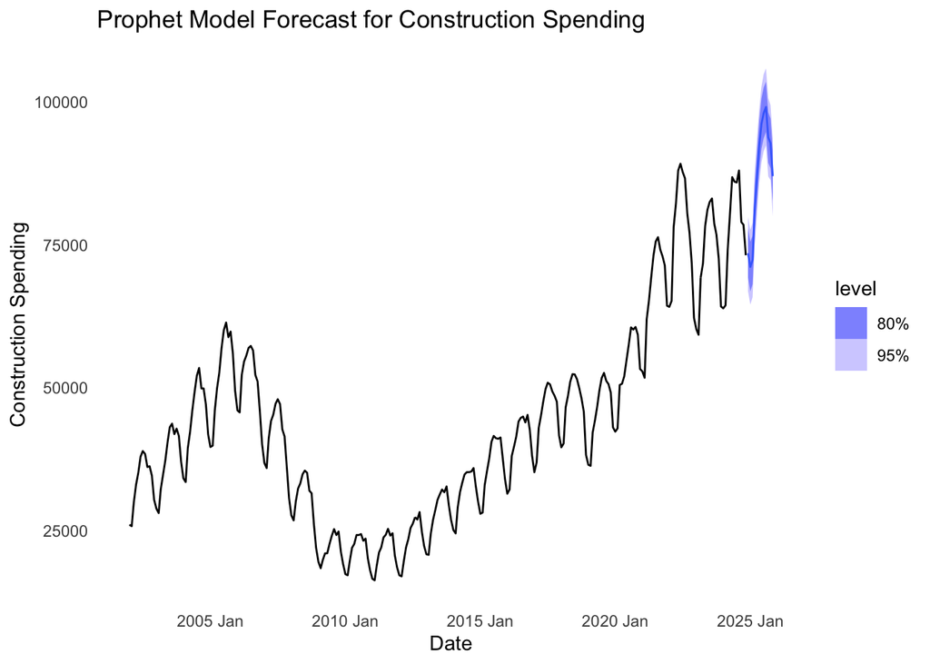

```r
# Generate forecasts for the next 12 months
forecast_data <- prophet_model %>%
  forecast(h = "12 months")

# Plot the forecast
forecast_data %>%
  autoplot(construction_spending) +
  ggtitle("Prophet Model Forecast for Construction Spending") +
  xlab("Date") +
  ylab("Construction Spending")+
  theme_minimal()+
  theme(panel.grid = element_blank())
```

```r
# Convert forecast data into a well-formatted table
forecast_data %>%
  as_tibble() %>%
  select(Model = .model, Date = yearmonth, Forecast = .mean) %>%  # Rename columns for clarity
  mutate(Forecast = round(Forecast, 2)) %>%  # Round forecast values
  gt() %>%
  tab_header(
    title = md("**📈 Prophet Model Forecast for Construction Spending**"),
    subtitle = md("Forecasted values for the next 12 months")
  ) %>%
  cols_label(
    Model = "Model Type",
    Date = "Forecast Date",
    Forecast = "Predicted Spending ($)"
  ) %>%
  fmt_number(columns = Forecast, decimals = 2) %>%  # Format numbers with 2 decimal places
  tab_options(
    table.border.top.color = "black",
    table.border.bottom.color = "black",
    heading.title.font.size = 16,
    heading.subtitle.font.size = 12,
    column_labels.font.weight = "bold",
    row.striping.background_color = "lightgrey",  # Alternate row colors
    table_body.border.top.color = "grey80"
  ) %>%
  data_color(
    columns = Forecast,
    colors = scales::col_numeric(
      palette = c("lightblue", "blue"), domain = NULL
    )
  )
```

**📈 Prophet Model Forecast for Construction Spending**

Forecasted values for the next 12 months

[output not shown]

**Decomposing and Visualizing Time-Series Components**

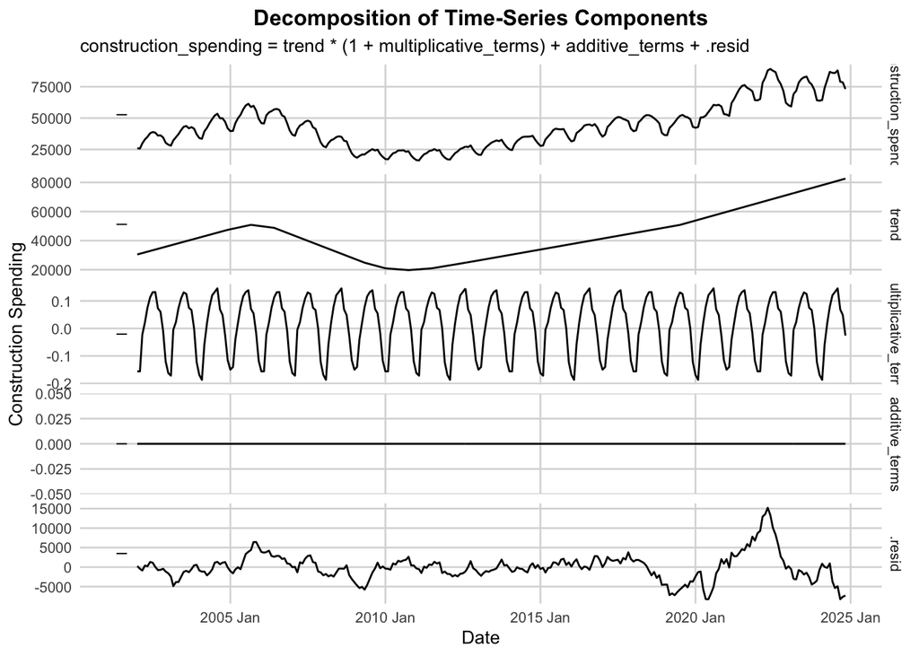

```r
# Extract time-series components (trend, seasonality, residuals)
components <- prophet_model %>%
  components()

# Enhanced visualization of decomposed components
autoplot(components) +
  ggtitle("Decomposition of Time-Series Components") +
  xlab("Date") +
  ylab("Construction Spending") +
  theme_minimal(base_size = 10) +
  theme(
    plot.title = element_text(face = "bold", hjust = 0.5),
    panel.grid.major = element_line(color = "grey85"),
    panel.grid.minor = element_blank()
  )
```

The decomposition plot provides a **detailed breakdown** of construction spending into its fundamental components: **trend, seasonality, and residuals**.

This decomposition analysis **validates the structure of the Prophet model**, confirming that both **trend and seasonal components** play a significant role in explaining construction spending patterns.

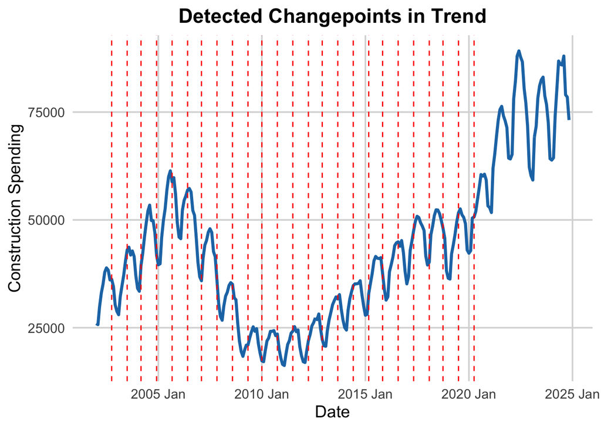

```r
# Extract detected changepoints
detected_changepoints <- prophet_model %>%
  glance() %>%
  select(changepoints) %>%
  unnest(changepoints) %>%
  pull(changepoints) %>%
  as.Date()  # Convert to Date format

#To look at detected changepoints
#detected_changepoints
# Plot actual data with detected changepoints
ggplot() +
  geom_line(data = construction_spending, aes(x = yearmonth, y = construction_spending),
            color = "#1f77b4", size = 1.2) +  # Actual data
  geom_vline(xintercept = detected_changepoints,
             color = "red", linetype = "dashed") +  # Changepoints
  ggtitle("Detected Changepoints in Trend") +
  xlab("Date") +
  ylab("Construction Spending") +
  theme_minimal(base_size = 14) +
  theme(
    plot.title = element_text(face = "bold", hjust = 0.5),
    panel.grid.major = element_line(color = "grey85"),
    panel.grid.minor = element_blank()
  )
```

The **red dashed vertical lines** highlight the **changepoints** where the model detected significant shifts in trend. These changepoints suggest periods where **construction spending experienced structural changes**, likely due to **economic shifts, policy implementations, or external market conditions**.

This changepoint analysis ensures that the model **effectively captures structural shifts** in construction spending while maintaining a balance between **flexibility and robustness** in trend estimation.

```r
# Refit Prophet model with optimized changepoint parameters
prophet_model_adj <- construction_spending %>%
  model(
    Prophet = prophet(
      construction_spending ~ growth("linear", n_changepoints = 10) +  # Optimized changepoints
        season(period = "year", type = "multiplicative", order = 6)   # Adjusted seasonality
    )
  )

# Extract and print detected changepoints
detected_changepoints <- prophet_model_adj %>%
  glance() %>%
  select(changepoints) %>%
  unnest(changepoints) %>%
  pull(changepoints) %>%
  as.Date()

print(detected_changepoints)
```

```
 [1] "2003-11-01" "2005-09-01" "2007-07-01" "2009-05-01" "2011-02-01"
 [6] "2012-12-01" "2014-10-01" "2016-08-01" "2018-06-01" "2020-04-01"
```

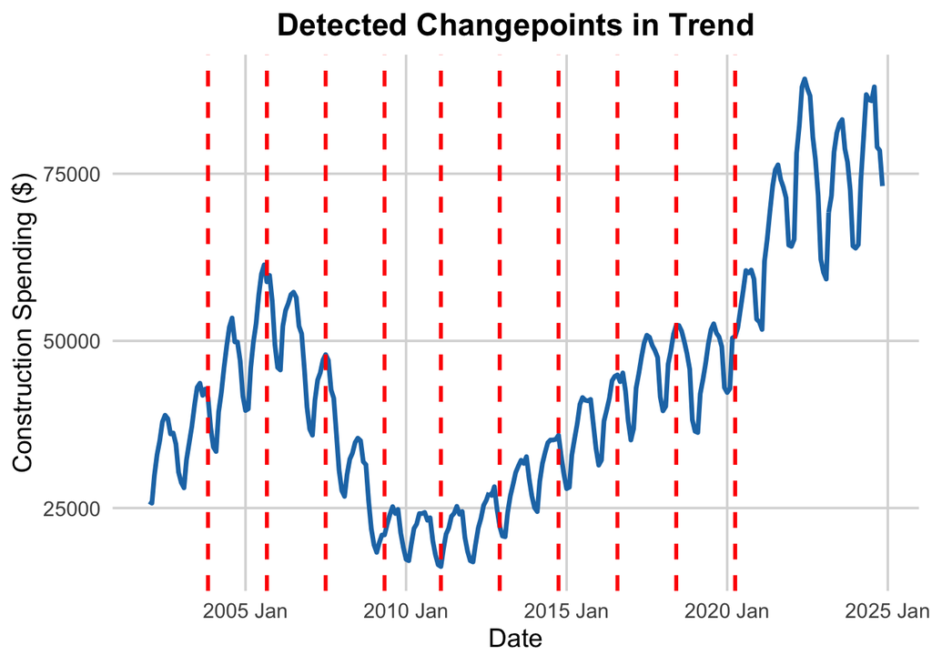

```r
# Generate forecasts for the optimized model
forecast_linear <- prophet_model_adj %>%
  forecast(h = "12 months")


# Plot actual data with detected changepoints
ggplot() +
  geom_line(data = construction_spending, aes(x = yearmonth, y = construction_spending),
            color = "#1f77b4", size = 1.2) +  # Actual data
  geom_vline(xintercept = as.numeric(detected_changepoints),
             color = "red", linetype = "dashed", size = 1) +  # Changepoints
  ggtitle("Detected Changepoints in Trend") +
  xlab("Date") +
  ylab("Construction Spending ($)") +
  theme_minimal(base_size = 14) +
  theme(
    plot.title = element_text(face = "bold", hjust = 0.5),
    panel.grid.major = element_line(color = "grey85"),
    panel.grid.minor = element_blank()
  )
```

Observations:

The **linear growth model provides a strong baseline forecast**, capturing historical patterns and growth trends. However, if real-world constraints suggest a saturation point, a **logistic growth model** should be explored for a more realistic long-term forecast.

```r
# Define cap and floor values (20% above max, 20% below min)
cap_value <- quantile(construction_spending$construction_spending, 0.99) * 1.2
floor_value <- quantile(construction_spending$construction_spending, 0.01) * 0.8

# Add cap and floor values to the dataset
construction_spending <- construction_spending %>%
  mutate(cap = cap_value, floor = floor_value)

# Create a future dataset for 12 months ahead and apply cap & floor
future_data <- new_data(construction_spending, h = "12 months") %>%
  mutate(cap = cap_value, floor = floor_value)

# Fit Prophet model using logistic growth
prophet_model_logistic <- construction_spending %>%
  model(
    Prophet = prophet(
      construction_spending ~ growth("logistic", cap = cap, floor = floor) +
        season(period = "year", type = "multiplicative", order = 6)  # Ensure seasonality order
    )
  )

glance(prophet_model_logistic)
```

```
# A tibble: 1 × 3
  .model   sigma changepoints
  <chr>    <dbl> <list>
1 Prophet 12920. <tibble [25 × 2]>
```

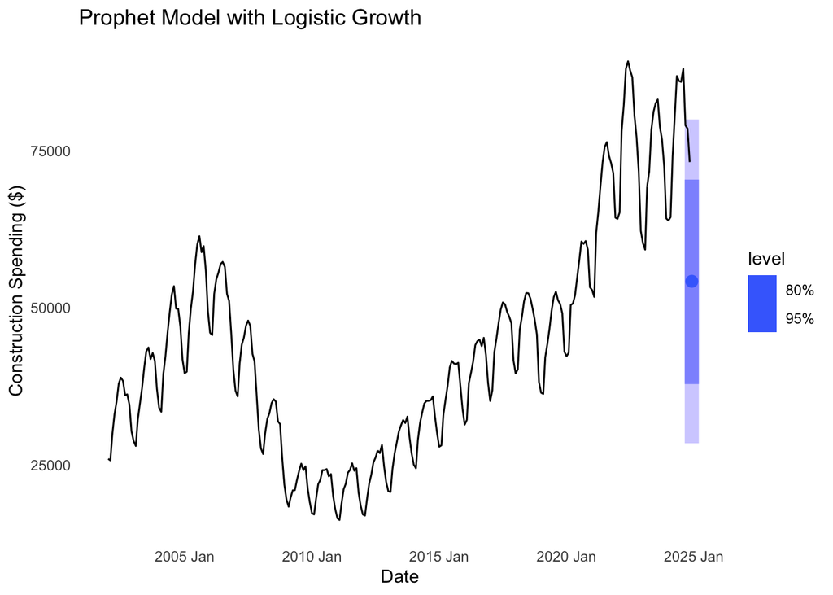

```r
# Generate forecast
forecast_logistic <- prophet_model_logistic %>%
  forecast(new_data = future_data)

# Plot Logistic Growth Model
autoplot(forecast_logistic, construction_spending) +
  ggtitle("Prophet Model with Logistic Growth") +
  xlab("Date") +
  ylab("Construction Spending ($)") +
  theme_minimal() +
  theme(panel.grid = element_blank())
```

Observations on the Prophet Model with Logistic Growth